# 3.1 Practical: hierarchical models

Benjamin Rosenbaum

October 23, 2019

Aim: learn what a random effect is.

Learn about **hierarchical** levels of parameters. Bayesian statistics is great for hierearchical models!

Think in terms of **no pooling**, **partial pooling** and **complete pooling** of parameters rather than **random effects** and **fixed effects**.

# Setup

```r
rm(list=ls())
library(rstan)
library(coda)
library(BayesianTools)
setwd("~/git/bayesian-intro/")

rstan_options(auto_write = TRUE)
options(mc.cores = 3)
```

# Read dataset

We load an example dataset from Kruschke “Doing Bayesian Data Analysis” https://sites.google.com/site/doingbayesiandataanalysis

It contains information on the lifespan (`Longevity`) of male fruitflies depending on their sexual activity.

Sexual activity was experimentally manipulated by different numbers of pregnant or virgin female fruitflies (`CompanionNumber`).

```r
df = read.csv("~/git/bayesian-intro/data/FruitflyDataReduced.csv")
head(df)
```

```
##   Longevity CompanionNumber Thorax
## 1        35       Pregnant8   0.64
## 2        37       Pregnant8   0.68
## 3        49       Pregnant8   0.68
## 4        46       Pregnant8   0.72
## 5        63       Pregnant8   0.72
## 6        39       Pregnant8   0.76
```

```r
str(df)
```

```
## 'data.frame':    125 obs. of  3 variables:
##  $ Longevity      : int  35 37 49 46 63 39 46 56 63 65 ...
##  $ CompanionNumber: Factor w/ 5 levels "None0","Pregnant1",..: 3 3 3 3 3 3 3 3 3 3 ...
##  $ Thorax         : num  0.64 0.68 0.68 0.72 0.72 0.76 0.76 0.76 0.76 0.76 ...
```

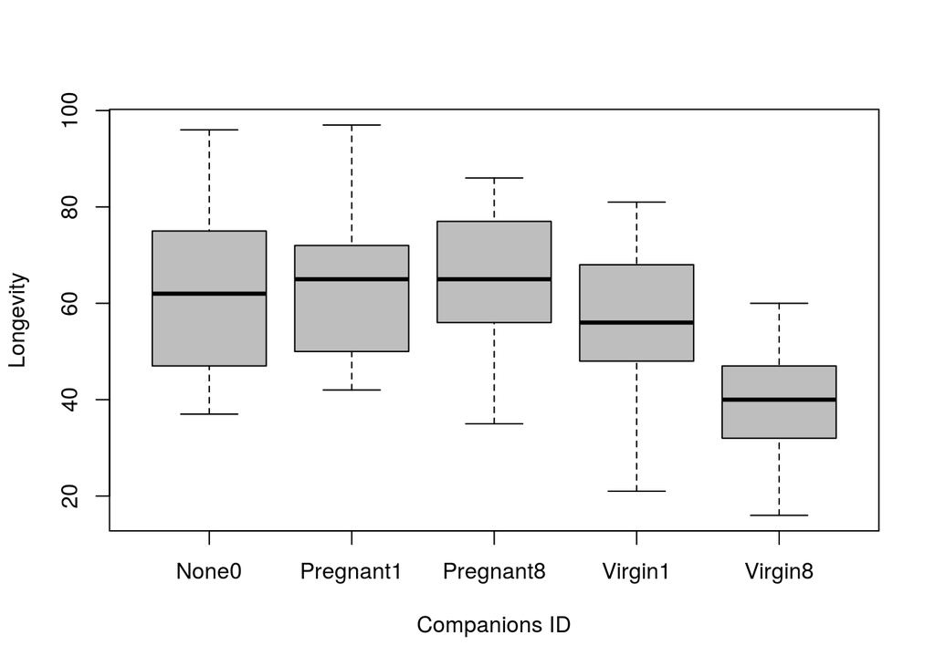

```r
boxplot(Longevity ~ CompanionNumber, data=df,
        ylab="Longevity",
        xlab="Companions ID",
        col="grey")
```

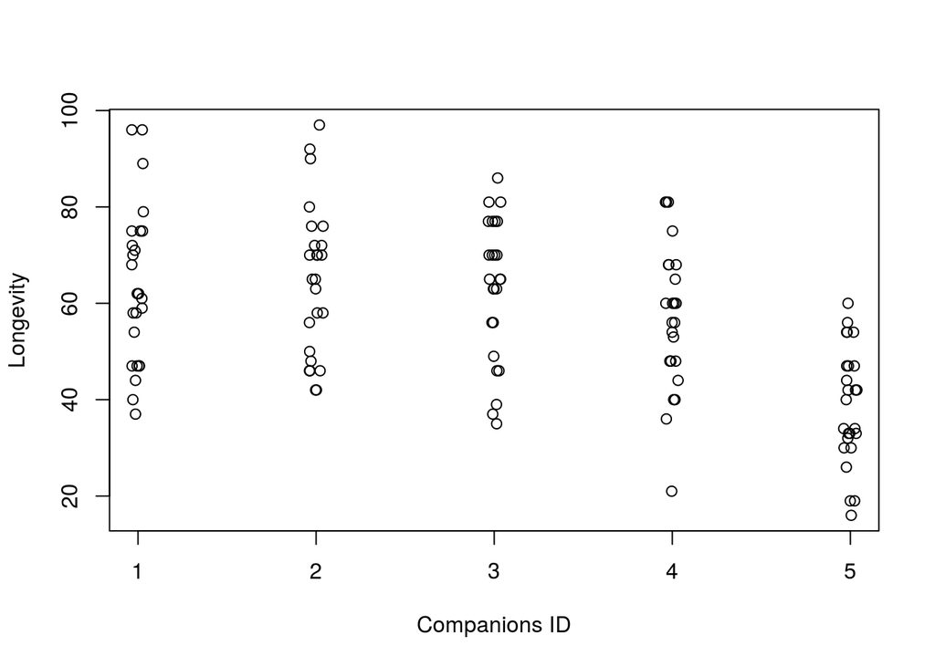

```r
plot(0, 0, xlim =c(1,5), ylim = range(df$Longevity), type = "n",
     ylab="Longevity",
     xlab="Companions ID")
points(Longevity ~ jitter(as.numeric(CompanionNumber), factor=0.2), data=df)
```

The following approach is similar to frequentist ANOVA.

# No pooling / Fixed effects model

We want to estimate the mean longevity per group, and test if there are differences between groups.

The statistical model is identical to yesterday’s “t-test” model, but now there are more than 2 groups:

$$y_i \sim~ \text{normal}(\mu_{group_i}, \sigma),\quad i=1,...,n$$

Note that there are no assumptions on $\mu_j$, i.e. the means of the different groups are estimated independently.

“group” is treated as a fixed effect.

This is also called “no pooling”, i.e. no information on the $\mu_j$ is pooled across the groups. Keep that in mind for later!

Here, we used the same variance for each group ($\sigma$), but we could also use different sigmas.

When preparing the data for Stan, note that we use `as.integer()` to code the factorial variable `group`, so we can use it as an index.

```r
data = list(y = df$Longevity,
            group = as.integer(df$CompanionNumber),
            n = nrow(df),
            n_group = 5)

data
```

```
## $y
##   [1] 35 37 49 46 63 39 46 56 63 65 56 65 70 63 65 70 77 81 86 70 70 77 77
##  [24] 81 77 40 37 44 47 47 47 68 47 54 61 71 75 89 58 59 62 79 96 58 62 70
##  [47] 72 75 96 75 46 42 65 46 58 42 48 58 50 80 63 65 70 70 72 97 46 56 70
##  [70] 70 72 76 90 76 92 21 40 44 54 36 40 56 60 48 53 60 60 65 68 60 81 81
##  [93] 48 48 56 68 75 81 48 68 16 19 19 32 33 33 30 42 42 33 26 30 40 54 34
## [116] 34 47 47 42 47 54 54 56 60 44
##
## $group
##   [1] 3 3 3 3 3 3 3 3 3 3 3 3 3 3 3 3 3 3 3 3 3 3 3 3 3 1 1 1 1 1 1 1 1 1 1
##  [36] 1 1 1 1 1 1 1 1 1 1 1 1 1 1 1 2 2 2 2 2 2 2 2 2 2 2 2 2 2 2 2 2 2 2 2
##  [71] 2 2 2 2 2 4 4 4 4 4 4 4 4 4 4 4 4 4 4 4 4 4 4 4 4 4 4 4 4 4 5 5 5 5 5
## [106] 5 5 5 5 5 5 5 5 5 5 5 5 5 5 5 5 5 5 5 5
##
## $n
## [1] 125
##
## $n_group
## [1] 5
```

We use (very) weakly informative prior information on the $\mu_j$, but note that the priors for $\mu_j$ are assigned independently!

```r
stan_code_nopool = '
data {
  int n;
  int n_group;
  real y[n];
  int group[n];
}
parameters {
  real<lower=0> mu[n_group];
  real<lower=0> sigma;
}
model {
  // priors
  for (j in 1:n_group){
    mu[j] ~ normal(0,100);
  }
  sigma ~ normal(0,100);
  // likelihood
  for(i in 1:n){
    y[i] ~ normal(mu[group[i]], sigma);
  }
}
'

stan_model_nopool = stan_model(model_code=stan_code_nopool)
# save(stan_model_nopool, file="stan_code_nopool.RData")
# load("stan_code_nopool.RData")

fit_nopool  = sampling(stan_model_nopool,
                       data=data,
                       chains=3,
                       iter=2000,
                       warmup=1000
)

print(fit_nopool, digits=3, probs=c(0.025, 0.975))
```

```
## Inference for Stan model: 609496b639a1ef1cb920e08a95f7c476.
## 3 chains, each with iter=2000; warmup=1000; thin=1;
## post-warmup draws per chain=1000, total post-warmup draws=3000.
##
##           mean se_mean    sd     2.5%    97.5% n_eff  Rhat
## mu[1]   63.503   0.045 3.090   57.571   69.437  4681 0.999
## mu[2]   64.698   0.045 2.980   58.753   70.470  4375 0.999
## mu[3]   63.334   0.047 3.016   57.657   69.234  4202 1.000
## mu[4]   56.673   0.050 3.039   50.760   62.778  3706 1.000
## mu[5]   38.741   0.043 2.947   32.968   44.546  4726 1.001
## sigma   14.985   0.017 0.973   13.239   16.977  3399 1.000
## lp__  -377.966   0.050 1.798 -382.266 -375.476  1282 1.003
##
## Samples were drawn using NUTS(diag_e) at Mon Oct 14 14:10:13 2019.
## For each parameter, n_eff is a crude measure of effective sample size,
## and Rhat is the potential scale reduction factor on split chains (at
## convergence, Rhat=1).
```

```
## ci_level: 0.8 (80% intervals)
```

```
## outer_level: 0.95 (95% intervals)
```

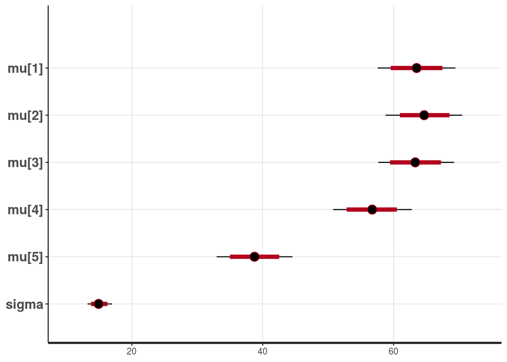

```r
plot(fit_nopool)
```

```r
# plot(fit_nopool, pars="mu")
# plot(As.mcmc.list(fit_nopool)) # from coda package
```

As in the “t-test” example from yesterday, we can look at the individual differences between groups, also called “contrasts”.

E.g., the posterior distribution of $\mu_4-\mu_5$.

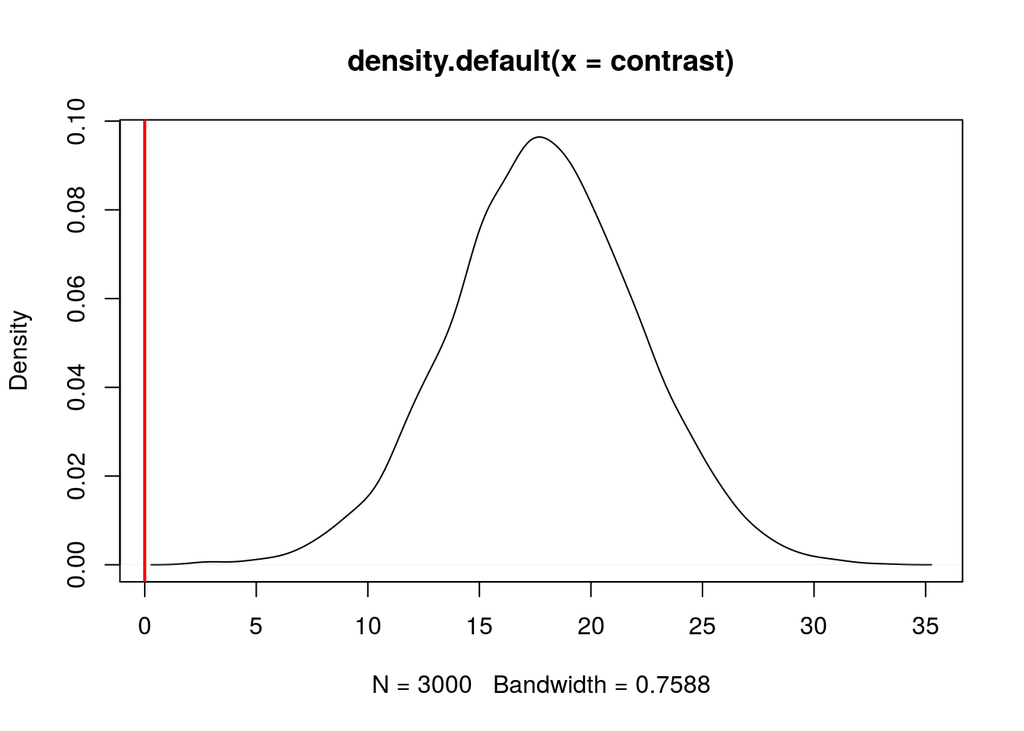

```r
posterior_nopool = as.matrix(fit_nopool)

contrast = posterior_nopool[,"mu[4]"]-posterior_nopool[,"mu[5]"]

plot(density(contrast))
abline(v=0, col="red", lwd=2)
```

# Partial pooling / Random effects model

Until now, we assumed that the different group means are completely independent.

However, we can assume that the longevity of fruitflies is not completely independent.

We can assume there is a joint mean and each group mean differs from this joint mean with a group-level standard deviation.

And we can explicitely model that:
$$\begin{align}
y_i &\sim \text{normal}(\mu_{group_i}, \sigma), \quad i=1,...,n \quad (n\ \text{observations}) \\
\mu_j &\sim~ \text{normal}(\mu^{total}, \sigma^{total}), \quad j=1,...,m \quad (m\ \text{groups})
\end{align}$$

$\sigma$ describes within-groups variation of response values.

$\sigma^{total}$ describes between-groups variation of group means.

Here, group is treated as a random effect.

Because some information is shared / pooled across groups, this is also called “partial pooling”.

$\mu^{total}$ and $\sigma^{total}$ are also parameters that are estimated from the data.

Because $\mu_j$’s distribution depends on $\mu^{total}$ and $\sigma^{total}$, this is a hierarchical model.

Like all other parameters, they will be assigned a prior distribution, too.

For the joint mean $\mu^{total}$, we can use the same expectation we used for the group means before.

For the between-groups standard deviation $\sigma^{total}$, it is standard procedure to use half-Chauchy distributions (more heavy-tailed than normal distribution).

The partial pooling model differs from the no pooling model above only in the joint distribution of the $\mu_j$ and additional parameters $\mu^{total}$ and $\sigma^{total}$.

```r
stan_code_partpool = '
data {
  int n;
  int n_group;
  real y[n];
  int group[n];
}
parameters {
  real<lower=0> mu[n_group];
  real<lower=0> sigma;
  real<lower=0> mu_total;
  real<lower=0> sigma_total;
}
model {
  // priors
  mu_total ~ normal(0, 100);
  sigma_total ~ cauchy(0, 10);

  for (j in 1:n_group){
    mu[j] ~ normal(mu_total, sigma_total);
  }
  sigma ~ normal(0,100);

  // likelihood
  for(i in 1:n){
    y[i] ~ normal(mu[group[i]], sigma);
  }
}
'

stan_model_partpool = stan_model(model_code=stan_code_partpool)
# save(stan_model_partpool, file="stan_code_partpool.RData")
# load("stan_code_partpool.RData")

fit_partpool  = sampling(stan_model_partpool,
                         data=data,
                         chains=3,
                         iter=2000,
                         warmup=1000
)

print(fit_partpool, digits=3, probs=c(0.025, 0.975))
```

```
## Inference for Stan model: 4e303d18d4f5c560bb3bfed64c8f7c19.
## 3 chains, each with iter=2000; warmup=1000; thin=1;
## post-warmup draws per chain=1000, total post-warmup draws=3000.
##
##                 mean se_mean    sd     2.5%    97.5% n_eff  Rhat
## mu[1]         63.027   0.047 2.920   57.348   68.679  3928 0.999
## mu[2]         64.242   0.047 2.868   58.655   69.917  3751 1.000
## mu[3]         62.868   0.045 3.001   56.811   68.679  4505 1.000
## mu[4]         56.673   0.041 2.902   50.983   62.529  4998 1.000
## mu[5]         40.190   0.055 3.201   33.810   46.649  3411 1.000
## sigma         14.967   0.015 0.942   13.237   16.966  3965 1.000
## mu_total      57.304   0.128 6.108   45.242   70.101  2290 1.000
## sigma_total   12.310   0.128 5.635    5.685   26.196  1933 1.000
## lp__        -386.504   0.066 2.187 -391.651 -383.325  1105 1.000
##
## Samples were drawn using NUTS(diag_e) at Mon Oct 14 14:10:48 2019.
## For each parameter, n_eff is a crude measure of effective sample size,
## and Rhat is the potential scale reduction factor on split chains (at
## convergence, Rhat=1).
```

```
## ci_level: 0.8 (80% intervals)
```

```
## outer_level: 0.95 (95% intervals)
```

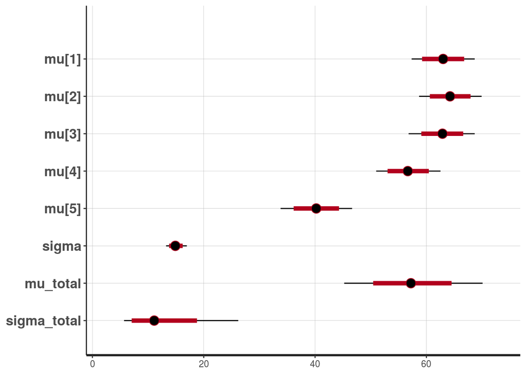

```r
plot(fit_partpool)
```

```r
# plot(fit_partpool, pars="mu")
# plot(As.mcmc.list(fit_partpool)) # from coda package
```

# Comparison

Now we compare the results of the “no pooling” and the “partial pooling” models.

The means and 95% confidence intervals of the $\mu_j$ can directly be extracted in a summary.

```r
summary_nopool = summary(fit_nopool)$summary
summary_nopool
```

```
##             mean    se_mean        sd       2.5%        25%        50%
## mu[1]   63.50274 0.04516286 3.0898570   57.57089   61.39836   63.51721
## mu[2]   64.69844 0.04504862 2.9795381   58.75287   62.66905   64.67100
## mu[3]   63.33399 0.04652697 3.0160020   57.65680   61.28447   63.29446
## mu[4]   56.67345 0.04992730 3.0393068   50.76033   54.64042   56.72824
## mu[5]   38.74117 0.04286436 2.9468129   32.96804   36.80865   38.74717
## sigma   14.98502 0.01669450 0.9732631   13.23868   14.29654   14.92911
## lp__  -377.96628 0.05020987 1.7978530 -382.26635 -378.94550 -377.65272
##              75%      97.5%    n_eff      Rhat
## mu[1]   65.61388   69.43651 4680.733 0.9992351
## mu[2]   66.68658   70.47018 4374.565 0.9992989
## mu[3]   65.47711   69.23377 4201.978 0.9996110
## mu[4]   58.66258   62.77764 3705.723 0.9999134
## mu[5]   40.63735   44.54568 4726.203 1.0013389
## sigma   15.59297   16.97712 3398.708 0.9995126
## lp__  -376.63869 -375.47607 1282.124 1.0033779
```

```r
summary_partpool = summary(fit_partpool)$summary
summary_partpool
```

```
##                   mean    se_mean        sd        2.5%        25%
## mu[1]         63.02691 0.04659541 2.9201682   57.347723   61.11405
## mu[2]         64.24195 0.04682509 2.8680028   58.654533   62.27627
## mu[3]         62.86797 0.04470422 3.0006118   56.810655   60.88157
## mu[4]         56.67304 0.04105219 2.9022942   50.983316   54.78773
## mu[5]         40.19044 0.05480082 3.2007675   33.809874   38.07691
## sigma         14.96723 0.01496635 0.9424577   13.236923   14.33674
## mu_total      57.30416 0.12764195 6.1076245   45.242285   53.74602
## sigma_total   12.31041 0.12816731 5.6347782    5.684936    8.54796
## lp__        -386.50365 0.06581200 2.1872025 -391.650840 -387.72880
##                    50%        75%      97.5%    n_eff      Rhat
## mu[1]         63.00707   64.95150   68.67928 3927.619 0.9992719
## mu[2]         64.24436   66.15438   69.91741 3751.474 1.0004356
## mu[3]         62.88584   64.83324   68.67864 4505.288 1.0002689
## mu[4]         56.65529   58.53842   62.52854 4998.160 0.9996538
## mu[5]         40.21421   42.27098   46.64878 3411.412 1.0002705
## sigma         14.90122   15.57302   16.96554 3965.446 0.9997043
## mu_total      57.21058   60.68443   70.10094 2289.590 1.0002672
## sigma_total   11.10289   14.41986   26.19586 1932.854 0.9995830
## lp__        -386.14700 -384.90117 -383.32476 1104.505 0.9995261
```

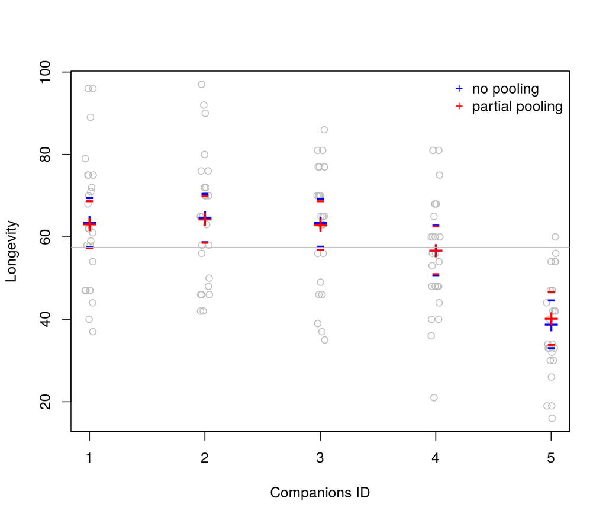

```r
plot(0, 0, xlim =c(1,5), ylim = range(df$Longevity), type = "n",
     ylab="Longevity",
     xlab="Companions ID")
points(Longevity ~ jitter(as.numeric(CompanionNumber), factor=0.2), data=df,
       col="grey")

points(summary_nopool[1:5, "mean"], pch="+", col="blue", cex=2)
points(summary_nopool[1:5, "2.5%"], pch="-", col="blue", cex=2)
points(summary_nopool[1:5, "97.5%"], pch="-", col="blue", cex=2)

points(summary_partpool[1:5, "mean"], pch="+", col="red", cex=2)
points(summary_partpool[1:5, "2.5%"], pch="-", col="red", cex=2)
points(summary_partpool[1:5, "97.5%"], pch="-", col="red", cex=2)

abline(h=mean(df$Longevity), col="grey")

legend("topright", legend=c("no pooling","partial pooling"), pch=c("+","+"), col=c("blue","red"), bty="n")
```

The difference between “no pooling” and “partial pooling” estimates is that extreme values tend to be pulled towards the joint mean by partial pooling (**shrinkage**).

Statistical power is borrowed across groups.

This can be helpful if some groups have a low number of observations.

In addition to both models, there is also **complete pooling**. Here, all information across groups would be pooled:
$$y_i \sim \text{normal}(\mu, \sigma),\quad i=1,...n$$
There is no effect of group included, i.e. all groups share the same mean.

“partial pooling” is a compromise between “no pooling” and “complete pooling”.